# Combine_tutorial

Anna Qualieri

7 May 2017

# **GenomicRanges**: **Granges** and **GRangesList**

Let’s start by loading the [GenomicRanges](http://bioconductor.org/packages/release/bioc/html/GenomicRanges.html) package via *biocLite*:

```r
> source("https://bioconductor.org/biocLite.R")
> biocLite("GenomicRanges")
> # biocLite('rtracklayer')
> biocLite("Rsamtools")
```

Load the packages necessary for this analysis into R. You can use the *install.packages(package = “mypackage”)* for every CRAN package below than is not already installed in your R session or *biocLite* for *Bioconductor* packages.

```r
> library(GenomicRanges)
> library(Rsamtools)
> # library(rtracklayer)
> library(ggplot2)
> library(png)
> library(grid)
```

## *GRanges*

Now that we are familiar with the basic structure and functionality of *GRanges* objects we are going to explore other ways of manipulating their information as well as ways to compare different *GRanges* objects.

Imagine you have done a ChIP-Seq experiment on *Sample 1* and your output is a set of ranges. Let’s start by manually creating this very simple *GRanges* objects with regions only on *chr1* and *chr2*.

```r
> # Sample 1
> gr_S1 <- GRanges(seqnames = Rle(c("chr1", "chr2"), c(3, 2)), ranges = IRanges(start = c(5,
+     8, 20, 8, 18), end = c(11, 15, 26, 16, 21), names = c(paste("Peak_", 1:5,
+     sep = ""))), strand = Rle(strand(c("*")), c(5)), peak_coverage = rbinom(n = 5,
+     size = 10, prob = 0.6))
>
> gr_S1
```

```
## GRanges object with 5 ranges and 1 metadata column:
##          seqnames    ranges strand | peak_coverage
##             <Rle> <IRanges>  <Rle> |     <integer>
##   Peak_1     chr1  [ 5, 11]      * |             5
##   Peak_2     chr1  [ 8, 15]      * |             6
##   Peak_3     chr1  [20, 26]      * |             6
##   Peak_4     chr2  [ 8, 16]      * |             5
##   Peak_5     chr2  [18, 21]      * |             6
##   -------
##   seqinfo: 2 sequences from an unspecified genome; no seqlengths
```

A very common analysis to perform is to evaluate to what extent and where your ChIP-Seq peaks overlap with some **features**, such as genes, exons, other ChIP-Seq peaks, etc… As an example we create a simple gene annotation to use with the ranges created above.

```r
> # Gene annotation
> genes <- GRanges(seqnames = Rle(c("chr1", "chr2"), c(2, 2)), ranges = IRanges(start = c(7,
+     17, 7, 23), end = c(15, 23, 14, 26), names = c(paste("Gene_", 1:4, sep = ""))),
+     strand = Rle(strand(c("+", "+")), c(2, 2)))
>
> genes
```

```
## GRanges object with 4 ranges and 0 metadata columns:
##          seqnames    ranges strand
##             <Rle> <IRanges>  <Rle>
##   Gene_1     chr1  [ 7, 15]      +
##   Gene_2     chr1  [17, 23]      +
##   Gene_3     chr2  [ 7, 14]      +
##   Gene_4     chr2  [23, 26]      +
##   -------
##   seqinfo: 2 sequences from an unspecified genome; no seqlengths
```

Figure is a simple way of plotting ranges stored into *Granges* object using *geom_rect* from *ggplot2*. Even though there are available more advanced ways of plotting genomic data, this simple strategy is sufficient for the purpose of this tutorial. This is an example of how any *GRanges* object can be converted to a *data.frame* via *data.frame(myGranges)*.

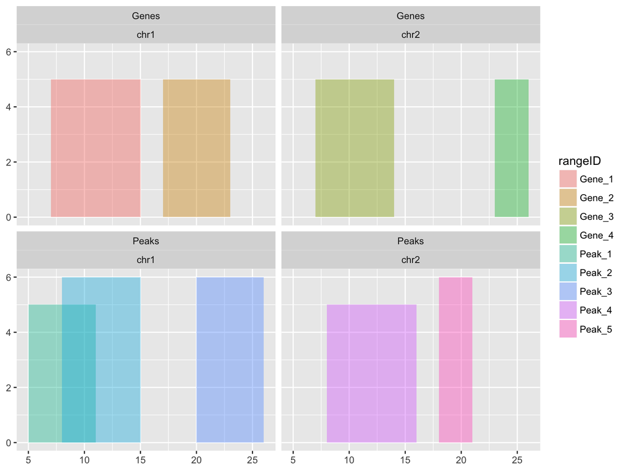

Graphic representation of the GRanges objects created above.

```r
> gr <- data.frame(rbind(data.frame(gr_S1), cbind(data.frame(genes), peak_coverage = 5)))
> gr$rangeID <- c(names(gr_S1), names(genes))
> gr$Sample <- c(rep("Peaks", length(gr_S1)), rep("Genes", length(genes)))
> ggplot(data = gr, aes(xmin = start, xmax = end, ymin = 0, ymax = peak_coverage)) +
+     geom_rect(aes(fill = rangeID), alpha = 0.4) + facet_wrap(~Sample + seqnames)
```

## Find overlaps between two *GRanges* objects

From Figure one notices that the two ranges in *chr1* from *Sample 1* are overlapping. This happens in ChIP-Seq experiments for example when there is a very broad peak and several peaks are called in place of one. Usually, it is helpful to simplify these situations with the aim of reducing a *GRanges* object to its minimal set of ranges, merging all such overlapping regions. This can be easily achieved with the *reduce()* function:

```r
> gr_S1_reduced <- reduce(gr_S1)
> gr_S1_reduced
```

```
## GRanges object with 4 ranges and 0 metadata columns:
##       seqnames    ranges strand
##          <Rle> <IRanges>  <Rle>
##   [1]     chr1  [ 5, 15]      *
##   [2]     chr1  [20, 26]      *
##   [3]     chr2  [ 8, 16]      *
##   [4]     chr2  [18, 21]      *
##   -------
##   seqinfo: 2 sequences from an unspecified genome; no seqlengths
```

```r
> length(gr_S1)
```

```
## [1] 5
```

```r
> length(gr_S1_reduced)
```

```
## [1] 4
```

One can also decide to keep every range distinct and evaluate the overlap for each of them. For this analysis we will keep the overlapping ranges as disticnt regions.

### *findOverlaps()*

Now, *findOverlaps()* can be used to detect overlap between the ChIP-Seq ranges and the gene annotation. *findOverlap()* by default looks for overlaps starting from 1bp between a *query* and a *subject* and it does not allow any gap between the overlapping ranges (arguments *minoverlap* and *maxgap* are 1 and 0 respectively by default).

```r
> overlaps <- findOverlaps(gr_S1, genes)
> overlaps
```

```
## Hits object with 4 hits and 0 metadata columns:
##       queryHits subjectHits
##       <integer>   <integer>
##   [1]         1           1
##   [2]         2           1
##   [3]         3           2
##   [4]         4           3
##   -------
##   queryLength: 5 / subjectLength: 4
```

Below is an example of what happens if we change the *maxgap* argument to 5, allowing 5bp to be present between ranges:

```r
> overlaps <- findOverlaps(gr_S1, genes, maxgap = 5)
> overlaps
```

```
## Hits object with 8 hits and 0 metadata columns:
##       queryHits subjectHits
##       <integer>   <integer>
##   [1]         1           1
##   [2]         2           1
##   [3]         2           2
##   [4]         3           1
##   [5]         3           2
##   [6]         4           3
##   [7]         5           3
##   [8]         5           4
##   -------
##   queryLength: 5 / subjectLength: 4
```

### *countOverlaps()*

The example used here is very simple and it straightforward to see how many ranges are overlapping with genes and viceversa. However, for more complex experiments the *countOverlaps()* function is a very useful tool to get a quick summary of the overlaps for every range.

```r
> N_overlaps <- countOverlaps(gr_S1, genes)
> N_overlaps
```

```
## Peak_1 Peak_2 Peak_3 Peak_4 Peak_5
##      1      1      1      1      0
```

## Nearest-methods in *GenomicRanges*

### *nearest()*

Will return a vector of indeces referring to the nearest neighbour *subject* for every range in *x*.

By default if one range overlaps with multiple genes then one overlap will be chosen at random:

```r
> GenomicRanges::nearest(x = gr_S1, subject = genes)
```

```
## [1] 1 1 2 3 4
```

Using *select = “all”* all overlaps will be return:

```r
> GenomicRanges::nearest(x = gr_S1, subject = genes, select = "all")
```

```
## Hits object with 5 hits and 0 metadata columns:
##       queryHits subjectHits
##       <integer>   <integer>
##   [1]         1           1
##   [2]         2           1
##   [3]         3           2
##   [4]         4           3
##   [5]         5           4
##   -------
##   queryLength: 5 / subjectLength: 4
```

You can also look for the nearest-neighbours within a single set of ranges:

```r
> GenomicRanges::nearest(gr_S1)
```

```
## [1] 2 1 2 5 4
```

### *distance()*

```r
> GenomicRanges::distance(x = gr_S1[1], y = genes)
```

```
## [1]  0  5 NA NA
```

```r
> GenomicRanges::distance(x = gr_S1[1:4], y = genes)
```

```
## [1]  0  1 NA  6
```

```r
> GenomicRanges::distance(x = gr_S1, y = genes)
```

```
## [1]  0  1 NA  6 NA
```

*distance()* is a symmetric function which means that it requires x and y to have to have the same lenght and if one is shorter than the other one it will be recycled to match the length of the longest. Also, the distance between two consecutive blocks is 0 not 1 which affects the notion of overlaps. If distance(x, y) == 0 then x and y can be either adjacent or overlapping ranges. For more information about the *distance()* function see ?IRanges::distance.

### *distanceToNearest()*

For every range in *x* it will return the index and the distance to its nearest neighbour in *subject*.

```r
> GenomicRanges::distanceToNearest(x = gr_S1, subject = genes)
```

```
## Hits object with 5 hits and 1 metadata column:
##       queryHits subjectHits |  distance
##       <integer>   <integer> | <integer>
##   [1]         1           1 |         0
##   [2]         2           1 |         0
##   [3]         3           2 |         0
##   [4]         4           3 |         0
##   [5]         5           4 |         1
##   -------
##   queryLength: 5 / subjectLength: 4
```

## *GRangesList*

*GRangesList* are lists of *GRanges* objects. In some instances it makes sense to store several set of ranges under a common parent. For example, when you call peaks on several technical replicates from a ChIP-Seq experiments and you want to store their output in one object. Anotehr example is when you would like to store different transcripts from the same gene under a common object. Below, this concept is illustrated with a simple example:

```r
> # Sample 1
> gr_S1 <- GRanges(seqnames = Rle(c("chr1", "chr2"), c(3, 2)), ranges = IRanges(start = c(5,
+     8, 20, 8, 18), end = c(11, 15, 26, 16, 21), names = c(paste("Peak_", 1:5,
+     sep = ""))), strand = Rle(strand(c("*")), c(5)), peak_coverage = rbinom(n = 5,
+     size = 10, prob = 0.6))
>
> gr_S1
```

```
## GRanges object with 5 ranges and 1 metadata column:
##          seqnames    ranges strand | peak_coverage
##             <Rle> <IRanges>  <Rle> |     <integer>
##   Peak_1     chr1  [ 5, 11]      * |             5
##   Peak_2     chr1  [ 8, 15]      * |             8
##   Peak_3     chr1  [20, 26]      * |             5
##   Peak_4     chr2  [ 8, 16]      * |             5
##   Peak_5     chr2  [18, 21]      * |             5
##   -------
##   seqinfo: 2 sequences from an unspecified genome; no seqlengths
```

```r
> # Sample 2
> gr_S2 <- GRanges(seqnames = Rle(c("chr2", "chr3"), c(3, 5)), ranges = IRanges(start = c(1:8),
+     width = 10, names = c(paste("Peak_", 1:8, sep = ""))), strand = Rle(strand(c("*")),
+     c(8)), peak_coverage = rbinom(n = 8, size = 10, prob = 0.6))
>
> gr_S2
```

```
## GRanges object with 8 ranges and 1 metadata column:
##          seqnames    ranges strand | peak_coverage
##             <Rle> <IRanges>  <Rle> |     <integer>
##   Peak_1     chr2   [1, 10]      * |             2
##   Peak_2     chr2   [2, 11]      * |             9
##   Peak_3     chr2   [3, 12]      * |             5
##   Peak_4     chr3   [4, 13]      * |             5
##   Peak_5     chr3   [5, 14]      * |             8
##   Peak_6     chr3   [6, 15]      * |             7
##   Peak_7     chr3   [7, 16]      * |             6
##   Peak_8     chr3   [8, 17]      * |             5
##   -------
##   seqinfo: 2 sequences from an unspecified genome; no seqlengths
```

```r
> # GRanges List
>
> list_ranges <- GRangesList(Sample1 = gr_S1, Sample2 = gr_S2)
```

Many of the functions learnt for *GRanges* can also be applied to *GRangesList* objects even though the output will have to be interepreted accordingly:

```r
> names(list_ranges)
```

```
## [1] "Sample1" "Sample2"
```

```r
> length(list_ranges)
```

```
## [1] 2
```

```r
> seqnames(list_ranges)
```

```
## RleList of length 2
## $Sample1
## factor-Rle of length 5 with 2 runs
##   Lengths:    3    2
##   Values : chr1 chr2
## Levels(3): chr1 chr2 chr3
##
## $Sample2
## factor-Rle of length 8 with 2 runs
##   Lengths:    3    5
##   Values : chr2 chr3
## Levels(3): chr1 chr2 chr3
```

```r
> strand(list_ranges)
```

```
## RleList of length 2
## $Sample1
## factor-Rle of length 5 with 1 run
##   Lengths: 5
##   Values : *
## Levels(3): + - *
##
## $Sample2
## factor-Rle of length 8 with 1 run
##   Lengths: 8
##   Values : *
## Levels(3): + - *
```

```r
> ranges(list_ranges)
```

```
## IRangesList of length 2
## $Sample1
## IRanges object with 5 ranges and 0 metadata columns:
##              start       end     width
##          <integer> <integer> <integer>
##   Peak_1         5        11         7
##   Peak_2         8        15         8
##   Peak_3        20        26         7
##   Peak_4         8        16         9
##   Peak_5        18        21         4
##
## $Sample2
## IRanges object with 8 ranges and 0 metadata columns:
##              start       end     width
##          <integer> <integer> <integer>
##   Peak_1         1        10        10
##   Peak_2         2        11        10
##   Peak_3         3        12        10
##   Peak_4         4        13        10
##   Peak_5         5        14        10
##   Peak_6         6        15        10
##   Peak_7         7        16        10
##   Peak_8         8        17        10
```

```r
> start(list_ranges)
```

```
## IntegerList of length 2
## [["Sample1"]] 5 8 20 8 18
## [["Sample2"]] 1 2 3 4 5 6 7 8
```

```r
> end(list_ranges)
```

```
## IntegerList of length 2
## [["Sample1"]] 11 15 26 16 21
## [["Sample2"]] 10 11 12 13 14 15 16 17
```

```r
> width(list_ranges)
```

```
## IntegerList of length 2
## [["Sample1"]] 7 8 7 9 4
## [["Sample2"]] 10 10 10 10 10 10 10 10
```

To get the number of ranges in every object of the list use *elementNROWS*:

```r
> elementNROWS(list_ranges)
```

```
## Sample1 Sample2
##       5       8
```

It is also possible to quickly combine all the element of a *GRangesList* into one *GRanges* object:

```r
> list_to_granges <- unlist(list_ranges)
> list_to_granges
```

```
## GRanges object with 13 ranges and 1 metadata column:
##                  seqnames    ranges strand | peak_coverage
##                     <Rle> <IRanges>  <Rle> |     <integer>
##   Sample1.Peak_1     chr1  [ 5, 11]      * |             5
##   Sample1.Peak_2     chr1  [ 8, 15]      * |             8
##   Sample1.Peak_3     chr1  [20, 26]      * |             5
##   Sample1.Peak_4     chr2  [ 8, 16]      * |             5
##   Sample1.Peak_5     chr2  [18, 21]      * |             5
##              ...      ...       ...    ... .           ...
##   Sample2.Peak_4     chr3   [4, 13]      * |             5
##   Sample2.Peak_5     chr3   [5, 14]      * |             8
##   Sample2.Peak_6     chr3   [6, 15]      * |             7
##   Sample2.Peak_7     chr3   [7, 16]      * |             6
##   Sample2.Peak_8     chr3   [8, 17]      * |             5
##   -------
##   seqinfo: 3 sequences from an unspecified genome; no seqlengths
```

To append two *GRanges* lists simply use the R concatenate command *c*:

```r
> # Sample 3
> gr_S3 <- GRanges(seqnames = Rle(c("chr1", "chr2"), c(3, 2)), ranges = IRanges(start = 20:24,
+     width = 8, names = c(paste("Peak_", 1:5, sep = ""))), strand = Rle(strand(c("*")),
+     c(5)), peak_coverage = rbinom(n = 5, size = 10, prob = 0.6))
>
> gr_S1
```

```
## GRanges object with 5 ranges and 1 metadata column:
##          seqnames    ranges strand | peak_coverage
##             <Rle> <IRanges>  <Rle> |     <integer>
##   Peak_1     chr1  [ 5, 11]      * |             5
##   Peak_2     chr1  [ 8, 15]      * |             8
##   Peak_3     chr1  [20, 26]      * |             5
##   Peak_4     chr2  [ 8, 16]      * |             5
##   Peak_5     chr2  [18, 21]      * |             5
##   -------
##   seqinfo: 2 sequences from an unspecified genome; no seqlengths
```

```r
> # Sample 4
> gr_S4 <- GRanges(seqnames = Rle(c("chr2", "chr3"), c(3, 5)), ranges = IRanges(start = 20:27,
+     width = 10, names = c(paste("Peak_", 1:8, sep = ""))), strand = Rle(strand(c("*")),
+     c(8)), peak_coverage = rbinom(n = 8, size = 10, prob = 0.6))
>
> gr_S4
```

```
## GRanges object with 8 ranges and 1 metadata column:
##          seqnames    ranges strand | peak_coverage
##             <Rle> <IRanges>  <Rle> |     <integer>
##   Peak_1     chr2  [20, 29]      * |             7
##   Peak_2     chr2  [21, 30]      * |             3
##   Peak_3     chr2  [22, 31]      * |             8
##   Peak_4     chr3  [23, 32]      * |             6
##   Peak_5     chr3  [24, 33]      * |             5
##   Peak_6     chr3  [25, 34]      * |             8
##   Peak_7     chr3  [26, 35]      * |             7
##   Peak_8     chr3  [27, 36]      * |             9
##   -------
##   seqinfo: 2 sequences from an unspecified genome; no seqlengths
```

```r
> # Second GRanges List
> list_ranges2 <- GRangesList(Sample3 = gr_S3, Sample4 = gr_S4)
```

```r
> append_lists <- c(list_ranges, list_ranges2)
> head(append_lists)
```

```
## GRangesList object of length 4:
## $Sample1
## GRanges object with 5 ranges and 1 metadata column:
##          seqnames    ranges strand | peak_coverage
##             <Rle> <IRanges>  <Rle> |     <integer>
##   Peak_1     chr1  [ 5, 11]      * |             5
##   Peak_2     chr1  [ 8, 15]      * |             8
##   Peak_3     chr1  [20, 26]      * |             5
##   Peak_4     chr2  [ 8, 16]      * |             5
##   Peak_5     chr2  [18, 21]      * |             5
##
## $Sample2
## GRanges object with 8 ranges and 1 metadata column:
##          seqnames  ranges strand | peak_coverage
##   Peak_1     chr2 [1, 10]      * |             2
##   Peak_2     chr2 [2, 11]      * |             9
##   Peak_3     chr2 [3, 12]      * |             5
##   Peak_4     chr3 [4, 13]      * |             5
##   Peak_5     chr3 [5, 14]      * |             8
##   Peak_6     chr3 [6, 15]      * |             7
##   Peak_7     chr3 [7, 16]      * |             6
##   Peak_8     chr3 [8, 17]      * |             5
##
## $Sample3
## GRanges object with 5 ranges and 1 metadata column:
##          seqnames   ranges strand | peak_coverage
##   Peak_1     chr1 [20, 27]      * |             7
##   Peak_2     chr1 [21, 28]      * |             5
##   Peak_3     chr1 [22, 29]      * |             5
##   Peak_4     chr2 [23, 30]      * |             2
##   Peak_5     chr2 [24, 31]      * |             7
##
## ...
## <1 more element>
## -------
## seqinfo: 3 sequences from an unspecified genome; no seqlengths
```

### Subsetting and looping over *GRanges* list

In many cases *GRanges* objects can be subsetted using the same rules that apply to normal lists or as sort of data frames in the following way:

```r
> # As a lit
> list_ranges[[1]]
```

```
## GRanges object with 5 ranges and 1 metadata column:
##          seqnames    ranges strand | peak_coverage
##             <Rle> <IRanges>  <Rle> |     <integer>
##   Peak_1     chr1  [ 5, 11]      * |             5
##   Peak_2     chr1  [ 8, 15]      * |             8
##   Peak_3     chr1  [20, 26]      * |             5
##   Peak_4     chr2  [ 8, 16]      * |             5
##   Peak_5     chr2  [18, 21]      * |             5
##   -------
##   seqinfo: 3 sequences from an unspecified genome; no seqlengths
```

```r
> list_ranges["Sample1"]
```

```
## GRangesList object of length 1:
## $Sample1
## GRanges object with 5 ranges and 1 metadata column:
##          seqnames    ranges strand | peak_coverage
##             <Rle> <IRanges>  <Rle> |     <integer>
##   Peak_1     chr1  [ 5, 11]      * |             5
##   Peak_2     chr1  [ 8, 15]      * |             8
##   Peak_3     chr1  [20, 26]      * |             5
##   Peak_4     chr2  [ 8, 16]      * |             5
##   Peak_5     chr2  [18, 21]      * |             5
##
## -------
## seqinfo: 3 sequences from an unspecified genome; no seqlengths
```

```r
> # As a data.frame object
> list_ranges[1, "peak_coverage"]
```

```
## GRangesList object of length 1:
## $Sample1
## GRanges object with 5 ranges and 1 metadata column:
##          seqnames    ranges strand | peak_coverage
##             <Rle> <IRanges>  <Rle> |     <integer>
##   Peak_1     chr1  [ 5, 11]      * |             5
##   Peak_2     chr1  [ 8, 15]      * |             8
##   Peak_3     chr1  [20, 26]      * |             5
##   Peak_4     chr2  [ 8, 16]      * |             5
##   Peak_5     chr2  [18, 21]      * |             5
##
## -------
## seqinfo: 3 sequences from an unspecified genome; no seqlengths
```

```r
> list_ranges["Sample1", "peak_coverage"]
```

```
## GRangesList object of length 1:
## $Sample1
## GRanges object with 5 ranges and 1 metadata column:
##          seqnames    ranges strand | peak_coverage
##             <Rle> <IRanges>  <Rle> |     <integer>
##   Peak_1     chr1  [ 5, 11]      * |             5
##   Peak_2     chr1  [ 8, 15]      * |             8
##   Peak_3     chr1  [20, 26]      * |             5
##   Peak_4     chr2  [ 8, 16]      * |             5
##   Peak_5     chr2  [18, 21]      * |             5
##
## -------
## seqinfo: 3 sequences from an unspecified genome; no seqlengths
```

At the same time it is possible to apply the general R function *lapply* and *sapply* in the same way as one would do for list objects:

```r
> lapply(list_ranges, length)
```

```
## $Sample1
## [1] 5
##
## $Sample2
## [1] 8
```

```r
> sapply(list_ranges, length)
```

```
## Sample1 Sample2
##       5       8
```

```r
> lapply(list_ranges, start)
```

```
## $Sample1
## [1]  5  8 20  8 18
##
## $Sample2
## [1] 1 2 3 4 5 6 7 8
```

```r
> Reduce(c, list_ranges)
```

```
## GRanges object with 13 ranges and 1 metadata column:
##          seqnames    ranges strand | peak_coverage
##             <Rle> <IRanges>  <Rle> |     <integer>
##   Peak_1     chr1  [ 5, 11]      * |             5
##   Peak_2     chr1  [ 8, 15]      * |             8
##   Peak_3     chr1  [20, 26]      * |             5
##   Peak_4     chr2  [ 8, 16]      * |             5
##   Peak_5     chr2  [18, 21]      * |             5
##      ...      ...       ...    ... .           ...
##   Peak_4     chr3   [4, 13]      * |             5
##   Peak_5     chr3   [5, 14]      * |             8
##   Peak_6     chr3   [6, 15]      * |             7
##   Peak_7     chr3   [7, 16]      * |             6
##   Peak_8     chr3   [8, 17]      * |             5
##   -------
##   seqinfo: 3 sequences from an unspecified genome; no seqlengths
```

Similar considerations apply for the other functions explored above like *findOverlaps()*, *countOverlaps()*, etc…

# *Rsamtools*

```r
> library(Rsamtools)
> which <- RangesList(seq1 = IRanges(1000, 2000), seq2 = IRanges(c(100, 1000),
+     c(1000, 2000)))
> what <- c("rname", "strand", "pos", "qwidth", "seq")
> param <- ScanBamParam(which = which, what = what)
> bamFile <- system.file("extdata", "ex1.bam", package = "Rsamtools")
> bam <- scanBam(bamFile, param = param)
```

# *Rtracklayer*

Now that the structure and manipulation of *GRanges* objects is clear, the *rtracklayer* package comes as a useful tool to import/export *GRanges* objects from and to different data formats commonly used in genomic analyses. *Rtracklayer* stands as an interface to mediate the crosstalk between R and genome browsers (UCSC built-in). Example of data files supported by this package are BED, bigWIG, wig, gff and gtf formats.

Another very important function of this package is to allow the visualisations of genomic annotation *tracks*. However, this part will not covered in the present tutorial. For more references see the [Rtracklayer Bioconductor page](http://bioconductor.org/packages/release/bioc/html/rtracklayer.html).

## Data formats

There is a very large number of different data formats used to store different sort of genomic data. In this tutororial only few of them will be covered as example. However, the UCSC genome growser offers a useful [FAQ page](https://genome.ucsc.edu/FAQ/FAQformat.html) where one can find the specification of all mandatory and optional fields for every data format.

## GTF and GFF Import/Export

The **GFF** and **GTF** are the preferred format used to store annotations and their exact specification is summarised in Figure and , taken from the UCSC browser.

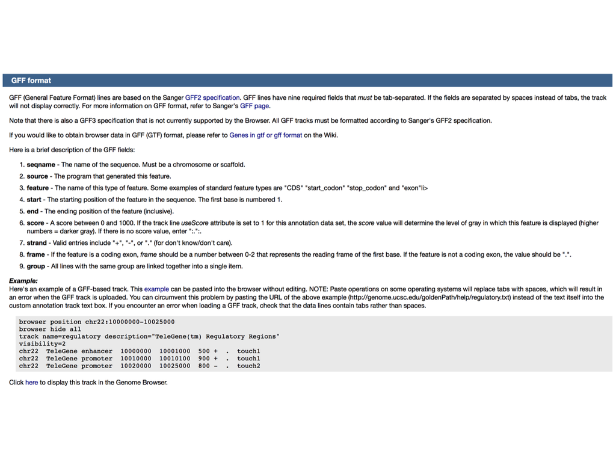

GFF and GTF format specification from the UCSC genome browser.

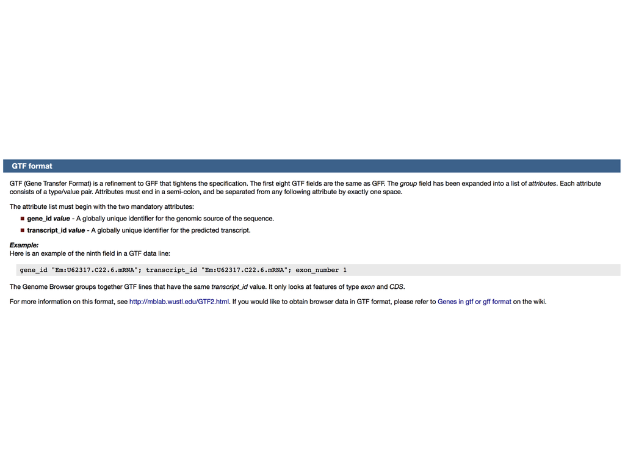

GFF and GTF format specification from the UCSC genome browser.

The function *rtracklayer::import()* is used to import all the supported data types into a *GRanges* object in R. The function recognises the format from the extension of the file but the argument *format* can be used to expliciclty define it. The function *rtracklayer::export()* works in the same way and it is used to export *GRanges* objects to files.

To check how to specify the file formats supported by the *import()* and *export()* functions, simply look up their help page /Library/Frameworks/R.framework/Versions/3.4/Resources/library/rtracklayer/help/export.

Following we import a gtf file containing the top 200 genes from hg38 UCSC gene annotation:

```r
> # Import gtf_path <- file.path(dir,'homo_sapiens_UCSC_hg38_200.gtf')
> gtf_path <- file.path("~/homo_sapiens_UCSC_hg38_200.gtf")
> gff_hg38_import <- rtracklayer::import(con = gtf_path)
> class(gff_hg38_import)
> gff_hg38_import
>
> # Export
> gtf_path <- file.path("~/homo_sapiens_UCSC_hg38_200_export.gtf")
> rtracklayer::export(object = gff_hg38_import, con = gtf_path)
```

## Challenge!

1. Create a simple *GRanges* object made out of 20 ranges and export it as a *gff* file.
2. Read the file back into R.
3. Print the number of rows of the *GRanges* object just imported and create a histogram of the widths of the ranges.

# Wiggle (WIG) and bigWIG file formats for graphing tracks

The [WIG](http://www.ensembl.org/info/website/upload/wig.html#tracklines) data format is used for the disply of dense continuous data, like scores. Every line in the file is an intervals and *WIG* files only allow equally spaced intervals. For intervals of variable width one should use the bedGraph format. There are two main data formats: the *variableStep* and the *fixedStep*. The *WIG* file is constituted by one or more blocks separated by declaration lines. Let’s go through them with two examples.

## variableStep

The following example is a *WIG* file with only one block of coordinates. The field *chrom* is required.

```bash
variableStep chrom=chr2
300701  12.5
300702  12.5
300703  12.5
300704  12.5
300705  12.5
```

The same file can be defined as follows using the *span* argument.

```bash
variableStep chrom=chr2 span=5
300701  12.5
```

## fixedStep

This format allows a more compact way of storing intervals. In this situation the *span* would not change the dimension of the file.

```bash
fixedStep chrom=chr3 start=400601 step=100
11
22
33
```

The [bigWig](https://genome.ucsc.edu/goldenpath/help/wiggle.html) file is created from a *WIG* file using a the *rtracklayer* function *wigToBigWig()*. It is the recommended format for very large data tracks due to the way in which data are compressed and stored in an indexed binary format. Usually whole-genome coverage vectors are stored as *bigWig*. Due to its compression there can be a minor loss in precision when the data are exported to other non binary format like the [bedGraph](https://genome.ucsc.edu/goldenpath/help/bedgraph.html). Howver, the loss is negligible when dealing with very large amount of data.

```r
> # wig_path <- file.path(dir,'exampleWIG.wig')
> wig_path <- file.path("~/exampleWIG.wig", genome = "hg19")
>
> import_wig <- rtracklayer::import(con = wig_path)
```

## bigWig Challenge

1. Convert the *WIG* file into a *bigWig* file and import the *bigWig* file into R.

```r
> # bigwig_path <- file.path(dir,'example_wigToBigWig.bw')
> bigwig_path <- file.path("~/example_wigToBigWig.bw")
>
> rtracklayer::wigToBigWig(wig_path, dest = bigwig_path, seqinfo = seqinfo(import_wig))
> import_bigwig <- rtracklayer::import(con = bigwig_path)
```

## Import only a region of the bigWig file

The *import* functions allows to load into a R only a specific regions defined using a *GRanges* object.

```r
> which_region <- GRanges(seqnames = "chr3", IRanges(start = 1, end = 5e+05))
> import_bigwig_region <- rtracklayer::import(con = bigwig_path, which = which_region)
```

# lifOver from different genome releases

```r
> library(AnnotationHub)
> ahub <- AnnotationHub()
> names(ahub)
>
> import_bigwig <- rtracklayer::import(con = bigwig_path)
>
> ahub.chain <- subset(ahub, rdataclass == "ChainFile" & species == "Homo sapiens")
> query(ahub.chain, c("hg18", "hg19"))
>
> chain <- ahub.chain[ahub.chain$title == "hg19ToHg18.over.chain.gz"]
> chain <- chain[[1]]
> gr.hg18 <- rtracklayer::liftOver(import_bigwig, chain)
> gr.hg18
```